# O que é o git e Github ?

Sérgio Carvalho

2018-11-28

### **O Git**

- É um sistema de controle de versão distribuído gratuito e de código aberto projetado para lidar com tudo, de projetos pequenos a muito grandes, com velocidade e eficiência, além de ser fácil de aprender Ele usa recursos como ramificação local barata, áreas de preparação convenientes e vários fluxos de trabalho.

> *Curiosidade: A microsoft migrou o seu sistema de controle de versão interna para o Git com o Github, pois somente para o windows há cerca de 4 mil desenvolvedores em todo mundo e o controle de versão da microsoft não estava dando conta.*

### **O Github**

- É um conjunto de repositórios publicados no Git e na internet, ou seja, além de o usuário poder fazer o controle de versão na máquina com o GitHub ele também pode fazer esse controle de versão online em um único repositório protegido por usuário e senha, isso é o Github, ou seja, é um local na internet onde estão os diversos repositórios do Git em todo mundo. O github é usado por 28 milhões de pessoas, a plataforma é o maior repositório de código de programas do mundo.

> Em 2018 a Microsoft comprou GitHub por US$ 7,5 bilhões.

# **Configurando o git**

O git guarda suas informações em três lugares.

```
  * git config (do sistema como um todo)
  * git config (do usuário)
  * git config (do projeto)
```

Configure informações de usuário para todos os repositórios locais, como o nome e o email que você quer ligado às suas transações de commit.

## Definindo configurações

#### de usuário

```
git config --global user.name "nome do usuario"
```

#### de e-mail

```
git config --global user.email "endereco-de-email"
```

#### do editor

```
git config --global core.editor "nome do editor"
```

## Retornando as configurações

#### do usuário

```
git config user.name
```

#### do e-mail

```
git config user.email
```

#### de tudo

```
git config --list
```

# **Iniciando uma repo**

Agora que já temos o git instalado e configurado iremos criar um repositório (repo, pasta) no qual colocaremos os arquivos de nosso projeto.

## Criando uma repo.

```
mkdir git-learn
```

#### entrando na repo git-learn

```
cd git-learn
```

#### reconhecendo a repo.

O comando **git init** faz com que a repo criada seja parte do ecossistema do git, ou seja, ele inicializa a repo e é o responsável por fazer com que o ecossistema do git enxergue todas as mudanças que ocorrerão na repo.

```
git init
```

#### o que há dentro do diretório git-learn ?

```
ls -la
```

Como abamos de inicializá-lo o diretório possui apenas um subdiretório .git.

#### o que há dentro do diretório .git ?

```
ls
```

Aqui estão algumas pastas responsáveis por:

- **config** : Configuração do Repositório.
- **HEAD** : Branch padrão.
- **branches**: Branches existentes do projeto.
- **description**: Descrição das branches.
- **hooks**: Catilhos para fazer certas ações,

e toda vez que inicializamos uma repo o git irá criar essas pastas para guardar todas as informações importantes para o bom gerenciamento da repo.

# **Workflow dos arquivos**.

Depois de algum tempo trabalhando com o git “+” github, você irá perceber que há um fluxo de trabalho no qual o usuário o compreende naturalmente, pois trata-se de estágios bem defindos que estabelecem um tipo de ciclo de vida dos arquivos.

> **O workflow dos arquivos pode ser entedido como um ciclo de vida dos arquivos em quatros estágios bem definidos.**
- **Untracked**
- **Unmodified**
- **Modified**
- **Staged**

Fonte: https://git-scm.com

## **Untracked**

É o momento em que o arquivo acabou de ser adicionado no repositório, mas ainda não foi visto pelo git, ou seja, o git não reconhece em seu repositório em nenhuma versão a existência deste arquivo.

## **Unmodified**

Depois que um arquivo é adicionado ele passa a ser considerado como não modificado, ou seja, ele já existe no git mas ainda não sofreu modificações.

## **Modified**

Após um arquivo ser reconhecido pelo git podemos então editá-lo e todo arquivo editado passa ao status de modificado.

## **Staged**

Depois do arquivo ser modificado podemos colocá-lo em uma área onde será criada uma versão, a qual é chamada de staged.

## **Commit**

Os arquivos comitados passam ao status de unmodified, pois uma vez que a versão de um arquivo foi criada e comentada nada foi alterado.

## **Workflow + comandos**

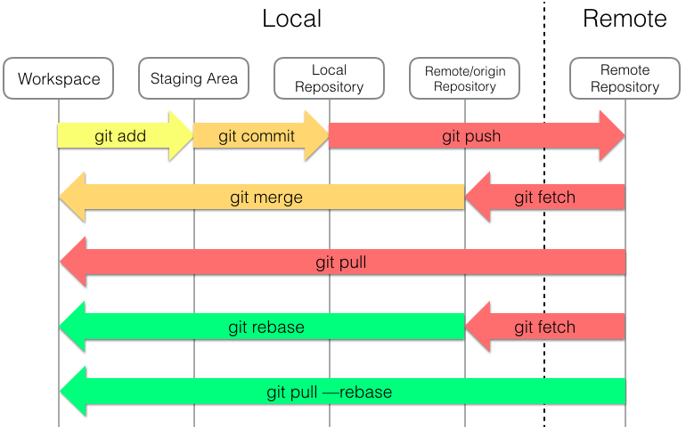

Imagem retirada do site https://medium.com/cs-note

# **Status do arquivo**

Antes de fazer modificações nos arquivos da repo, é altamente recomendado que você dê o comando **git status** que irá retornar os arquivos de acordo com o estágio no(s) qual(is) se encontra(m) no worflow. Por exemplo, suponha que após digitarmos **git status** observemos que há um arquivo no estágio **untracked** o que implica que ainda não podemos **commitá-lo**, sendo necessário primeiramente subir esse arquivo para o git usando o **git add [nome do arquivo]**.

## **git status**

Serve pra reportar como está o meu repositório neste momento.

```
git status
```

Se não existir nada ainda em seu repositório irá aparecer a seguinte mensagem:

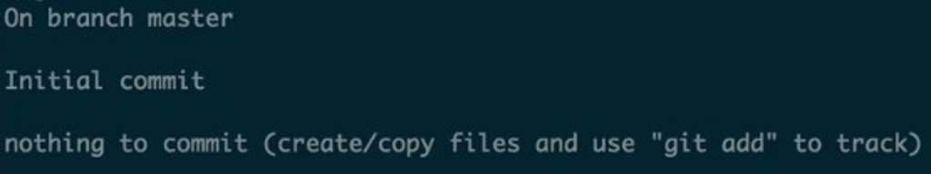

git stauts

- **On branch master**: significar que você está na branch master
- **Inicial commit** : ainda não tive nenhum commit
- **nothing to commit**: não tenho nada para commitar

Como ainda não há arquivos em nosso repositório, iremos criá-lo usando um editor de texto vim.

```
vim Readme.md
```

[figure not shown]

Criando um arquivo

- Criado o arquivo Readme.md criado vamos agora inserir um texto nele.
- Pressione a tecla i para passarmos ao modo de inserção.
- Digite a frase Curso básico de gite github.
- Pressione ESC para voltar ao modo de comando.
- Digite :wq e sem seguida pressione o Enter.

Obs: O comando (:wq) é utilizado para salvar (salve) o arquivo e sair (quit) do Vim.

Agora podemos verificar novamente o status

```
git status
```

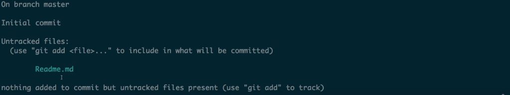

status untracked cycle life

Observe que o arquivo Readme.md está com seu status em untracked, ou seja, ele acabou de ser criado porém o git ainda não o reconhece, iremos adicioná-lo usando o comando **git add [nome do arquivo]** e em seguida digitaremos novamente o **git status**.

## **git add**

Faz o snapshot de um arquivo na preparação para versionamento.

```
git add Readme.md
```

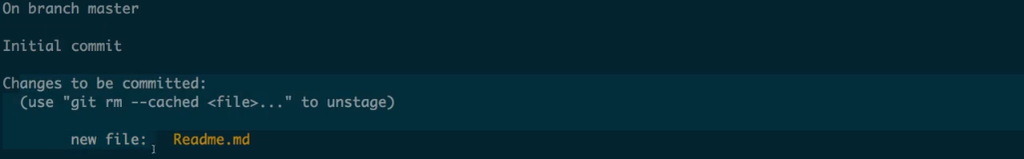

git add new file

# **Commitando arquivos**

> *O comando commit é usado no momento em que você quer avisar ao git que ele já pode criar uma image (snapshot,versão) do(s) arquivo(s) que está(ão) no repositório.*

- commit_ars.png
- very_status.png

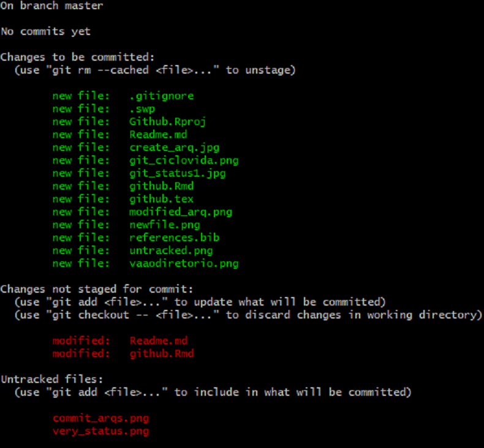

status and cycle file

estão no estágio **untracked**, ou seja, ainda não foram reconhecidos pelo ecossistema do git e, para isto, precisamos adicioná-los através do comando **git add [nome do arquivo]**. Já os arquivos,

- Readme.md
- github.Rmd

são reconhecidos pelo git, porém como foram modificados precisam ser adicionados **git add** e commitados **git commit -m [nome do arquivo]** .

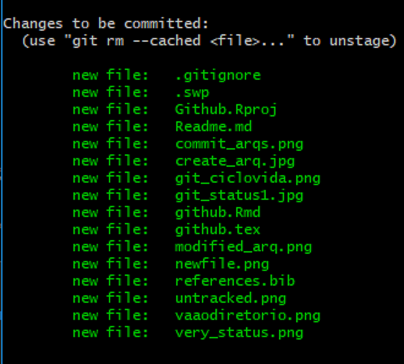

Arquivos a serem commitados

## **Primeiro commit**

> **No texto do commit é importante escrever o que realmente ocorreu com o arquivo, para que caso tenha que retornar a uma determinada versão você se lembre facilmente da alteração que foi feita, isso contribui em muito para o desenvolvimento de código em equipe.**

### Commitando o arquivo **Readme.md**.

[output not shown]

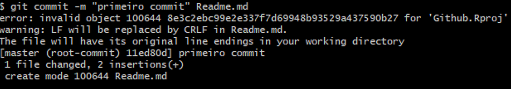

primeiro commit

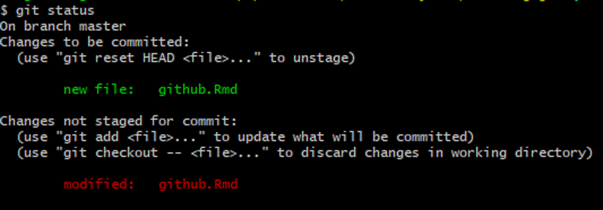

status depois do primeiro commit

# **Visualizando os logs**

A visualização dos *logs* nos permite ter acesso ao histórico das modificações realizadas em todos os arquivos da(s) repo(s).

## **Git log**

O comando **git log** lista os arquivos que foram versionados.

```
git logs
```

- swp
- github latex-referencias
- imagens
- projeto
- gitignore
- primeiro commit

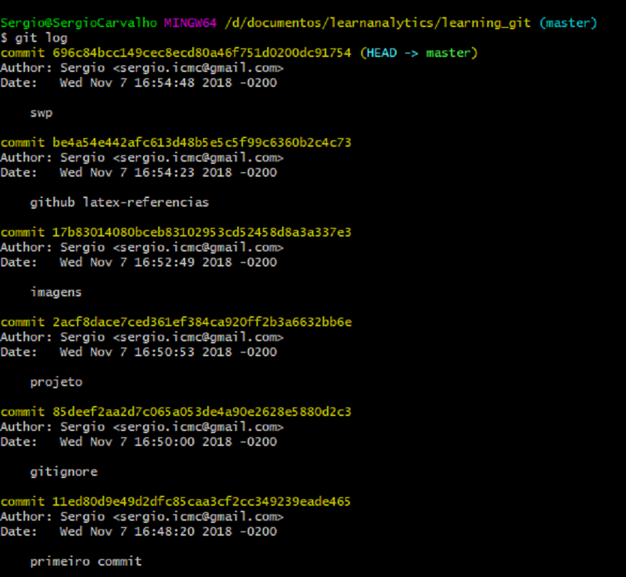

visualizando os logs

Perceba que após o termo **commit** há um código alpha numérico denominado por **hash**, ele será útil quando desejamos verificar a(s) modificação(ões) ocorrida(s) em um determinado arquivo. Além disso, também é retornado o usuário que realizou a(s) modificação(ões) e em qual(ais) data(s) ela(s) ocorreu(am).

## **Filtrando os logs**

Uma das formas de filtrar os logs é selecionando o author através do comando **git shortlog**. No exemplo abaixo observa-se que ao setar author = “sergio” há seis itens.

```
$ git shortlog --author="sergio"
Sergio (6):
      primeiro commit
      gitignore
      projeto
      imagens
      github latex-referencias
      swp
```

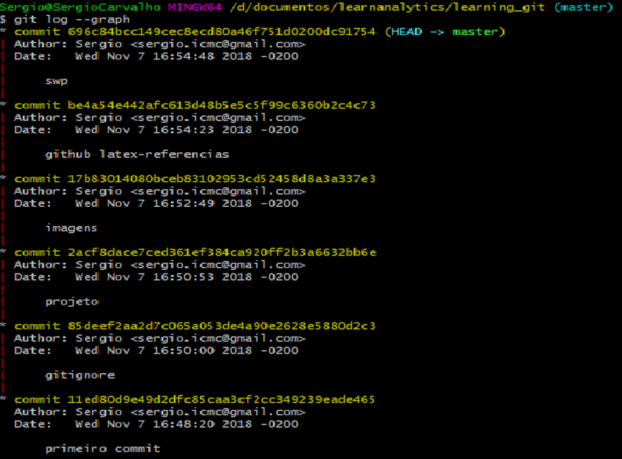

Visualizando os logs com git log –graph

# **Revise o histórico**

Verifique a evolução dos arquivos do projeto.

```
git log --follow [arquivo]
```

```
git log --follow [arquivo]
```

Lista o histórico de versões para um arquivo, incluindo mudanças de nome

## **Usando a hash para ver o commits**

O comando **git show** seguido pela **hash** de determinado **commit** nos mostra qual a alteração que houve ao commitar o arquivo.

```
git show [hash]
```

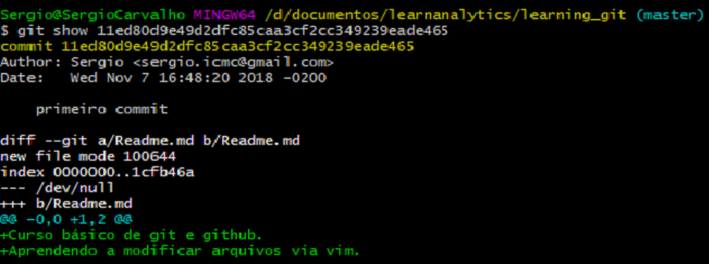

Verificações de commit

# **Usando o git diff**

O comando **git diff** permite a nós visualizarmos as mudanças feitas nos arquivos antes de fazer o commit e salvar a versão, ou seja, quando o arquivo encontrar-se no estágio *staged*.  
## **Exemplo:**

Pelo *git bash* iremos criar o arquivo *Comando_diff.md* e vamos trabalhar nele.

```
git subl Comando_diff.md
```

Agora digite: ‘entendendo o comando diff.’

### O que foi mudou ?

```
git diff
```

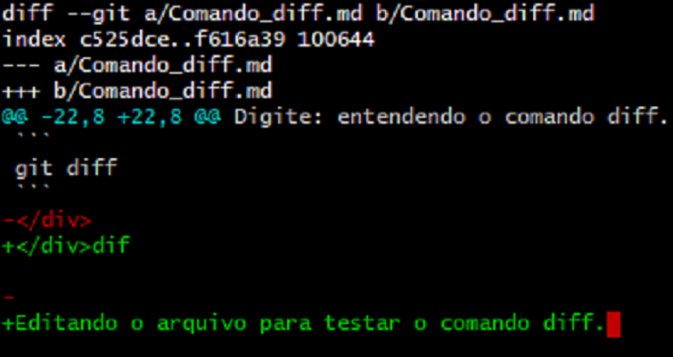

Verificações de commit

Observe que git coloca um sinal de ‘+’ indicando que houve alguma modificação isso nos ajuda no sentido de que podemos visualizar e revisar as mudanças antes de enivar para que o git salve uma versão, por isso é sempre interesse utilizar o git diff antes de realizar o commit.

### **Opções do git diff**

```
git diff --name-only
```

Nesta opção o git retorna somente o nome do arquivo modificado.

```
git diff --staged
```

Mostra a diferença entre arquivos preparados e suas últimas versões.

```
git diff [primerio-branch]...[segundo-branch]
```

Mostra a diferença de conteúdo entre dois branches

# **Faça mudanças**

No git há uma série de comando que permite ao usuários realizar mudanças quando for necessário, tais mudanças vão desde um *commit* até a remoção completa do arquivo independente de qual estágio esteja dentro do workflow.

## **Git checkout**

O git checkout é utilizado para nos ajudar a desfazer coisas, por exemplo, suponha que acabamos de realizar alguma modificação em um arquivo e ai, antes de commitar digitamos o comando git diff, na hipótese de termos feito algo errado ou que apenas não gostamos da modificação realizada podemos resetar o arquivo com o comando **git checkout** que o arquivo voltará ao seu status de conteúdo antes da modificação.

```
git diff checkout [nome do arquivo]
```

## **Git reset**

O comando git reset tem três variações:

- **git reset –soft**: reset o commit mas deixar o arquivo no staged para ser commitado novamente.
- **git reset –mixed**: reset o commit mas volta o arquivo para antes do unstaged, modified.
- **git reset –hard**: reset todo o arquivo como se o commit sido feito.

As três formas de uso do git reset, soft, mixed e hard, são acompanhadas da hash que indica que o reset será dado nas modificações posteriores a ela.

## **Altere arquivos versionados**

Remove o arquivo do diretório de trabalho e o prepara a remoção.

```
git rm [arquivo]
```

Remove o arquivo do controle de versão mas preserva o arquivo localmente.

```
git rm --cached [arquivo]
```

Muda o nome do arquivo e o prepara para o commit

```
git mv [arquivo-original] [arquivo-renomeado]
```

# **Mudanças em grupo**

No git é possível utilizar as branches para nomeaar uma série de commits e combinar os esforços completos.

## **Liste as Branches**.

```
git branch
```

Lista todos os branches locais no repositório atual.

## **Cria uma nova branch**

```
git branch [nome-do-branch]
```

## **Muda de branch**

```
git checkout [nome-do-branch]
```

Muda para o branch especificado e atualiza o diretório de trabalho.

## **Junta as branches**

```
git merge [nome-do-branch]
```

Combina o histórico do branch especificado ao branch atual.

## **Exclua a Branch**

```
git branch -d [nome-do-branch]
```

Exclui o branch especificado

# **O repositório remoto Github**

No github,

- Crie um repositório com o mesmo nome do nosso repositório local
- Em seguida, gere uma chave SSH em nosso computador de trabalho e adicioná-la ao github.

## **Obtenha uma URL existente**

Com o Git Bash criamos o repositório *learning_git* em *~/documents/estudos de analytics*.

### **O git clone**

*Se um projeto já foi configurado em um repositório central, o comando git clone é a maneira mais comum para os usuários obterem um clone de desenvolvimento local. Como git init, a clonagem é geralmente uma operação única. Depois que um desenvolvedor obtiver uma cópia de trabalho, todas as operações de controle de versão serão gerenciadas por meio de seu repositório local.*

```
git clone [repo url]
```

# **Suprima o monitoramento**

Ignore arquivos e diretórios temporários

- *.log
- build/
- temp-*

Um arquivo de texto chamado .gitignore suprime o versionamento acidental de arquivos e diretórios correspondentes aos padrões especificados.

```
git ls-files --others --ignored --exclude-standard
```

Lista todos os arquivos ignorados neste projeto.

# **Sincronize mudanças**

Registre um repositório remoto e troque o histórico de versão.

```
git fetch [nome-remoto]
```

Baixe todo o histórico de um repositório remoto.

```
git merge [nome-remoto]/[branch]
```

Combina o branch remoto ao branch local atual.

```
git push [alias] [branch]
```

Envia todos os commits do branch local para o GitHub.

```
git pull
```

Baixa o histórico e incorpora as mudanças.

# **Referências**

- [wiki-Git](https://pt.wikipedia.org/wiki/Git)
- [Learngitbranching”](https://learngitbranching.js.org)
- [Git-SCM](https://git-scm.com/book/en/v2)
- [GitLab](https://lab.github.com/courses)
- [Getting Git Right](https://www.atlassian.com/git)
- [PJ Wang](https://medium.com/@daniel820710)